# Travel Package Purchase Prediction

Background and Context

You are a Data Scientist for a tourism company named "Visit with us". The Policy Maker of the company wants to enable and establish a viable business model to expand the customer base.

A viable business model is a central concept that helps you to understand the existing ways of doing the business and how to change the ways for the benefit of the tourism sector.

One of the ways to expand the customer base is to introduce a new offering of packages.

Currently, there are 5 types of packages the company is offering - Basic, Standard, Deluxe, Super Deluxe, King. Looking at the data of the last year, we observed that 18% of the customers purchased the packages.

However, the marketing cost was quite high because customers were contacted at random without looking at the available information.

The company is now planning to launch a new product i.e. Wellness Tourism Package. Wellness Tourism is defined as Travel that allows the traveler to maintain, enhance or kick-start a healthy lifestyle, and support or increase one's sense of well-being.

However, this time company wants to harness the available data of existing and potential customers to make the marketing expenditure more efficient.

You as a Data Scientist at "Visit with us" travel company have to analyze the customers' data and information to provide recommendations to the Policy Maker and Marketing Team and also build a model to predict the potential customer who is going to purchase the newly introduced travel package.

## Objective

To predict which customer is more likely to purchase the newly introduced travel package.

## Data Dictionary

1) CustomerID: Unique customer ID 2) ProdTaken: Whether the customer has purchased a package or not (0: No, 1: Yes) 3) Age: Age of customer 4) TypeofContact: How customer was contacted (Company Invited or Self Inquiry) 5) CityTier: City tier depends on the development of a city, population, facilities, and living standards. The categories are ordered i.e. Tier 1 > Tier 2 > Tier 3 6) Occupation: Occupation of customer 7) Gender: Gender of customer 8) NumberOfPersonVisiting: Total number of persons planning to take the trip with the customer 9) PreferredPropertyStar: Preferred hotel property rating by customer 10) MaritalStatus: Marital status of customer 11) NumberOfTrips: Average number of trips in a year by customer 12) Passport: The customer has a passport or not (0: No, 1: Yes) 13) OwnCar: Whether the customers own a car or not (0: No, 1: Yes) 14) NumberOfChildrenVisiting: Total number of children with age less than 5 planning to take the trip with the customer 15) Designation: Designation of the customer in the current organization 16) MonthlyIncome: Gross monthly income of the customer

Customer interaction data:

1) PitchSatisfactionScore: Sales pitch satisfaction score 2) ProductPitched: Product pitched by the salesperson 3) NumberOfFollowups: Total number of follow-ups has been done by the salesperson after the sales pitch 4) DurationOfPitch: Duration of the pitch by a salesperson to the customer

```python
#pip install xgboost
```

```python
import pandas as pd
import numpy as np
import matplotlib.pyplot as plt
import seaborn as sns
pd.set_option("display.max_columns", None) # display all columns
pd.set_option("display.max_rows", 200)
from sklearn.model_selection import train_test_split
from sklearn.model_selection import GridSearchCV
from sklearn import metrics
from sklearn.ensemble import BaggingClassifier, RandomForestClassifier
from sklearn.tree import DecisionTreeClassifier
from sklearn import tree
from sklearn.ensemble import AdaBoostClassifier, GradientBoostingClassifier
from xgboost import XGBClassifier
from sklearn.ensemble import StackingClassifier
from sklearn.tree import DecisionTreeClassifier

# Libtune to tune model, get different metric scores
from sklearn import metrics
from sklearn.metrics import confusion_matrix, classification_report, accuracy_score, precision_score, recall_score, f1_score, roc_auc_score
from sklearn.model_selection import GridSearchCV
from sklearn.linear_model import LogisticRegression
```

```python
data=pd.read_excel("Tourism.xlsx", sheet_name="Tourism" )
```

```python
data.head()
```

|  | CustomerID | ProdTaken | Age | TypeofContact | CityTier | DurationOfPitch | Occupation | Gender | NumberOfPersonVisiting | NumberOfFollowups | ProductPitched | PreferredPropertyStar | MaritalStatus | NumberOfTrips | Passport | PitchSatisfactionScore | OwnCar | NumberOfChildrenVisiting | Designation | MonthlyIncome |
| --- | --- | --- | --- | --- | --- | --- | --- | --- | --- | --- | --- | --- | --- | --- | --- | --- | --- | --- | --- | --- |
| 0 | 200000 | 1 | 41.0 | Self Enquiry | 3 | 6.0 | Salaried | Female | 3 | 3.0 | Deluxe | 3.0 | Single | 1.0 | 1 | 2 | 1 | 0.0 | Manager | 20993.0 |
| 1 | 200001 | 0 | 49.0 | Company Invited | 1 | 14.0 | Salaried | Male | 3 | 4.0 | Deluxe | 4.0 | Divorced | 2.0 | 0 | 3 | 1 | 2.0 | Manager | 20130.0 |
| 2 | 200002 | 1 | 37.0 | Self Enquiry | 1 | 8.0 | Free Lancer | Male | 3 | 4.0 | Basic | 3.0 | Single | 7.0 | 1 | 3 | 0 | 0.0 | Executive | 17090.0 |
| 3 | 200003 | 0 | 33.0 | Company Invited | 1 | 9.0 | Salaried | Female | 2 | 3.0 | Basic | 3.0 | Divorced | 2.0 | 1 | 5 | 1 | 1.0 | Executive | 17909.0 |
| 4 | 200004 | 0 | NaN | Self Enquiry | 1 | 8.0 | Small Business | Male | 2 | 3.0 | Basic | 4.0 | Divorced | 1.0 | 0 | 5 | 1 | 0.0 | Executive | 18468.0 |

```python
print(f"Thre are {data.shape[0]} rows and {data.shape[1]} columns in the data")
```

```
Thre are 4888 rows and 20 columns in the data
```

```python
data.isnull().sum().sort_values() # there are missing values on the Age, DurationOfPitch, NumberOfFollowups, NumberOfTrips,NumberOfChildrenVisiting, and MonthlyIncome
```

```
CustomerID                    0
ProdTaken                     0
OwnCar                        0
CityTier                      0
PitchSatisfactionScore        0
Occupation                    0
Gender                        0
NumberOfPersonVisiting        0
Designation                   0
ProductPitched                0
MaritalStatus                 0
Passport                      0
TypeofContact                25
PreferredPropertyStar        26
NumberOfFollowups            45
NumberOfChildrenVisiting     66
NumberOfTrips               140
Age                         226
MonthlyIncome               233
DurationOfPitch             251
dtype: int64
```

```python
data.duplicated().sum() # there is no duplicated row
```

```
0
```

```python
data.dtypes # Data types of the variables are integer, float, and object; some variables should be categorical
```

```
CustomerID                    int64
ProdTaken                     int64
Age                         float64
TypeofContact                object
CityTier                      int64
DurationOfPitch             float64
Occupation                   object
Gender                       object
NumberOfPersonVisiting        int64
NumberOfFollowups           float64
ProductPitched               object
PreferredPropertyStar       float64
MaritalStatus                object
NumberOfTrips               float64
Passport                      int64
PitchSatisfactionScore        int64
OwnCar                        int64
NumberOfChildrenVisiting    float64
Designation                  object
MonthlyIncome               float64
dtype: object
```

```python
data.describe(include="all").T
```

|  | count | unique | top | freq | mean | std | min | 25% | 50% | 75% | max |
| --- | --- | --- | --- | --- | --- | --- | --- | --- | --- | --- | --- |
| CustomerID | 4888 | NaN | NaN | NaN | 202444 | 1411.19 | 200000 | 201222 | 202444 | 203665 | 204887 |
| ProdTaken | 4888 | NaN | NaN | NaN | 0.188216 | 0.390925 | 0 | 0 | 0 | 0 | 1 |
| Age | 4662 | NaN | NaN | NaN | 37.6223 | 9.31639 | 18 | 31 | 36 | 44 | 61 |
| TypeofContact | 4863 | 2 | Self Enquiry | 3444 | NaN | NaN | NaN | NaN | NaN | NaN | NaN |
| CityTier | 4888 | NaN | NaN | NaN | 1.65426 | 0.916583 | 1 | 1 | 1 | 3 | 3 |
| DurationOfPitch | 4637 | NaN | NaN | NaN | 15.4908 | 8.51964 | 5 | 9 | 13 | 20 | 127 |
| Occupation | 4888 | 4 | Salaried | 2368 | NaN | NaN | NaN | NaN | NaN | NaN | NaN |
| Gender | 4888 | 3 | Male | 2916 | NaN | NaN | NaN | NaN | NaN | NaN | NaN |
| NumberOfPersonVisiting | 4888 | NaN | NaN | NaN | 2.90507 | 0.724891 | 1 | 2 | 3 | 3 | 5 |
| NumberOfFollowups | 4843 | NaN | NaN | NaN | 3.70845 | 1.00251 | 1 | 3 | 4 | 4 | 6 |
| ProductPitched | 4888 | 5 | Basic | 1842 | NaN | NaN | NaN | NaN | NaN | NaN | NaN |
| PreferredPropertyStar | 4862 | NaN | NaN | NaN | 3.58104 | 0.798009 | 3 | 3 | 3 | 4 | 5 |
| MaritalStatus | 4888 | 4 | Married | 2340 | NaN | NaN | NaN | NaN | NaN | NaN | NaN |
| NumberOfTrips | 4748 | NaN | NaN | NaN | 3.23652 | 1.84902 | 1 | 2 | 3 | 4 | 22 |
| Passport | 4888 | NaN | NaN | NaN | 0.290917 | 0.454232 | 0 | 0 | 0 | 1 | 1 |
| PitchSatisfactionScore | 4888 | NaN | NaN | NaN | 3.07815 | 1.36579 | 1 | 2 | 3 | 4 | 5 |
| OwnCar | 4888 | NaN | NaN | NaN | 0.620295 | 0.485363 | 0 | 0 | 1 | 1 | 1 |
| NumberOfChildrenVisiting | 4822 | NaN | NaN | NaN | 1.18727 | 0.857861 | 0 | 1 | 1 | 2 | 3 |
| Designation | 4888 | 5 | Executive | 1842 | NaN | NaN | NaN | NaN | NaN | NaN | NaN |
| MonthlyIncome | 4655 | NaN | NaN | NaN | 23619.9 | 5380.7 | 1000 | 20346 | 22347 | 25571 | 98678 |

```python
df=data.copy()
```

#### Observation

1)There are 4888 rows and 20 columns in the data set. 2) There are missing values on some columns that should be handled. 3) There are no duplicated rows. 4) Some columns have float or integer data types which should be converted to categorical. 5) Age ranged from 18 to 61 years, and the mean score of age is 37.6. 6) There are 3 unique genders and 4 marital statuses. 7) CustomerID column should be dropped.

### Data Prosessing

```python
df=df.drop(["CustomerID"], axis=1)
```

```python
cat_list_col=["ProdTaken","CityTier","PreferredPropertyStar","Passport","OwnCar", "Gender","Occupation","TypeofContact","ProductPitched","MaritalStatus","Designation"]
```

```python
for column in cat_list_col:
    df[column]=df[column].astype("category")
```

```python
df.dtypes
```

```
ProdTaken                   category
Age                          float64
TypeofContact               category
CityTier                    category
DurationOfPitch              float64
Occupation                  category
Gender                      category
NumberOfPersonVisiting         int64
NumberOfFollowups            float64
ProductPitched              category
PreferredPropertyStar       category
MaritalStatus               category
NumberOfTrips                float64
Passport                    category
PitchSatisfactionScore         int64
OwnCar                      category
NumberOfChildrenVisiting     float64
Designation                 category
MonthlyIncome                float64
dtype: object
```

```python
cat_list = list(df.select_dtypes(include=['category']).columns)
cat_list
```

```
['ProdTaken',
 'TypeofContact',
 'CityTier',
 'Occupation',
 'Gender',
 'ProductPitched',
 'PreferredPropertyStar',
 'MaritalStatus',
 'Passport',
 'OwnCar',
 'Designation']
```

```python
for feature in cat_list:
    print(df[feature].value_counts())
    print("#"*70)
```

```
0    3968
1     920
Name: ProdTaken, dtype: int64
######################################################################
Self Enquiry       3444
Company Invited    1419
Name: TypeofContact, dtype: int64
######################################################################
1    3190
3    1500
2     198
Name: CityTier, dtype: int64
######################################################################
Salaried          2368
Small Business    2084
Large Business     434
Free Lancer          2
Name: Occupation, dtype: int64
######################################################################
Male       2916
Female     1817
Fe Male     155
Name: Gender, dtype: int64
######################################################################
Basic           1842
Deluxe          1732
Standard         742
Super Deluxe     342
King             230
Name: ProductPitched, dtype: int64
######################################################################
3.0    2993
5.0     956
4.0     913
Name: PreferredPropertyStar, dtype: int64
######################################################################
Married      2340
Divorced      950
Single        916
Unmarried     682
Name: MaritalStatus, dtype: int64
######################################################################
0    3466
1    1422
Name: Passport, dtype: int64
######################################################################
1    3032
0    1856
Name: OwnCar, dtype: int64
######################################################################
Executive         1842
Manager           1732
Senior Manager     742
AVP                342
VP                 230
Name: Designation, dtype: int64
######################################################################
```

# EDA

### Univariate Analysis

```python
def labeled_barplot(data, feature, percentage=False, n=None):
    total = len(data[feature])
    count = data[feature].nunique()
    if n is None:
        plt.figure(figsize=(count + 1, 6))
    else:
        plt.figure(figsize=(n + 1, 6))

    plt.xticks(rotation=45, fontsize=10)
    ax = sns.countplot(
        data=data,
        x=feature,
        palette="Set2",
        order=data[feature].value_counts().index[:n].sort_values(),
    )

    for p in ax.patches:
        if percentage == True:
            label = "{:.1f}%".format(
                100 * p.get_height() / total
            )
        else:
            label = p.get_height()

        x = p.get_x() + p.get_width() / 2
        y = p.get_height()

        ax.annotate(
            label,
            (x, y),
            ha="center",
            va="center",
            size=12,
            xytext=(0, 5),
            textcoords="offset points",
        )

    plt.show()
```

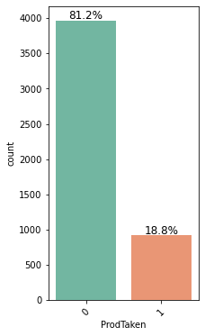

```
None
```

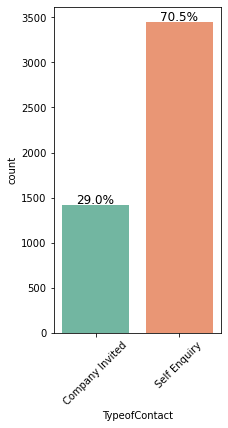

```
None
```

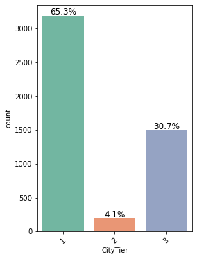

```
None
```

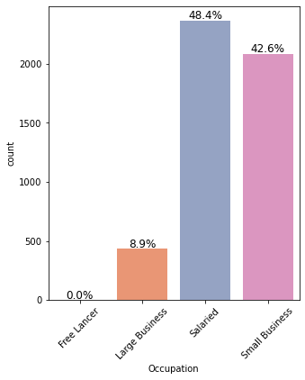

```
None
```

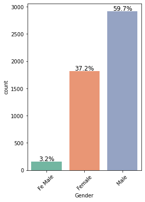

```
None
```

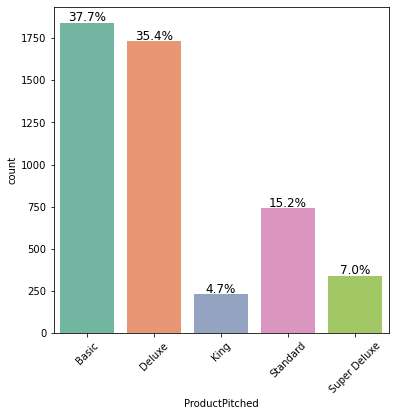

```
None
```

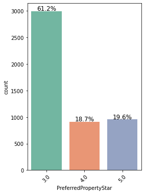

```
None
```

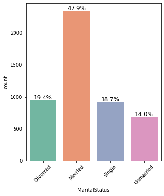

```
None
```

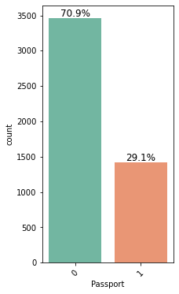

```
None
```

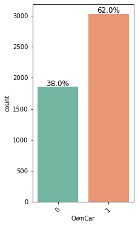

```
None
```

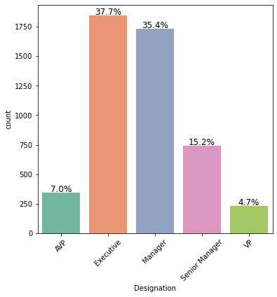

```
None
```

```python
for feature in cat_list:
    print(labeled_barplot(df, feature, percentage=True, n=None))
```

### Observation

1) 81.2% of the customers have not purchased a package. 2) 70.5% of the customers have contacted by themself, self-enquiry. 3) Tier one city (65.3%) is higher than the other tiers. 4) Almost 50% of the customers have a salaried career. 5) 59.7% of the customers are male, Female and Fe male should be merged. 6) Basic and Deluxe are the most popular products among the customers. 7) The customers most prefer Three-stars property. 8) Almost 50% of the customers are married. 9) Most customers (70.9%) do not have a password. 10) 62% of the customers have a car. 11) 37.7% of the customers are executives, and 4.7% are VP.

```python
def boxplot_hitogram(data, feature, figsize=(10, 5), kde=False, bins=None):

    f2, (ax_box2, ax_hist2) = plt.subplots(
        nrows=2,
        sharex=True,
        gridspec_kw={"height_ratios": (0.25, 0.75)},
        figsize=figsize,
    )
    sns.boxplot(
        data=data, x=feature, ax=ax_box2, showmeans=True, color="yellowgreen"
    )
    sns.histplot(
        data=data, x=feature, kde=kde, ax=ax_hist2, bins=bins, palette="pink"
    ) if bins else sns.histplot(
        data=data, x=feature, kde=kde, ax=ax_hist2
    )
    ax_hist2.axvline(
        data[feature].mean(), color="lime", linestyle="-"
    )
    ax_hist2.axvline(
        data[feature].median(), color="red", linestyle="--"
    )
```

```python
num_list= list(df.select_dtypes(include=['float64',"int64"]).columns)
num_list
```

```
['Age',
 'DurationOfPitch',
 'NumberOfPersonVisiting',
 'NumberOfFollowups',
 'NumberOfTrips',
 'PitchSatisfactionScore',
 'NumberOfChildrenVisiting',
 'MonthlyIncome']
```

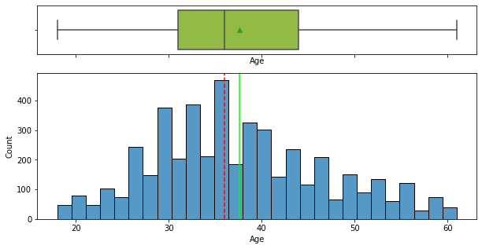

```python
boxplot_hitogram(df, "Age", figsize=(10, 5), kde=False, bins=None)
```

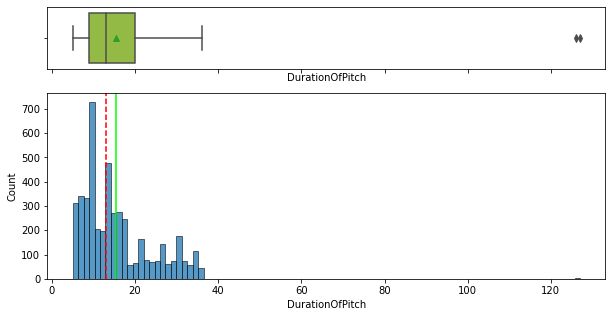

```python
boxplot_hitogram(df, "DurationOfPitch", figsize=(10, 5), kde=False, bins=None)
```

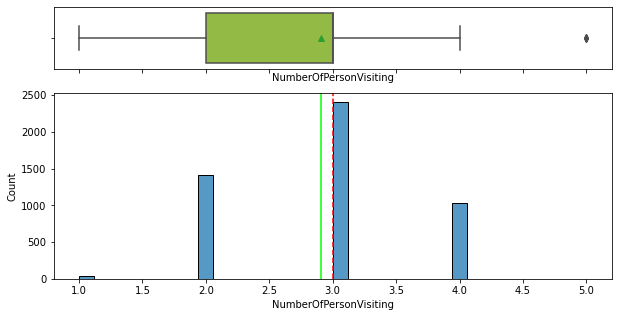

```python
boxplot_hitogram(df, "NumberOfPersonVisiting", figsize=(10, 5), kde=False, bins=None)
```

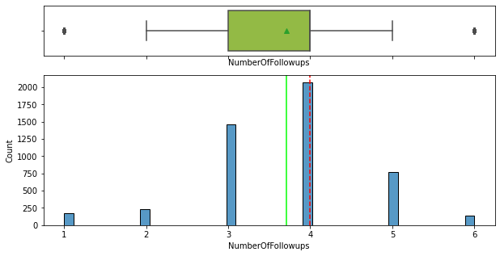

```python
boxplot_hitogram(df, "NumberOfFollowups", figsize=(10, 5), kde=False, bins=None)
```

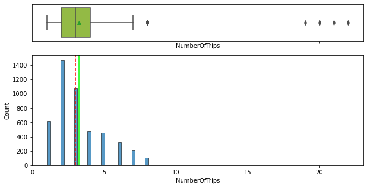

```python
boxplot_hitogram(df, "NumberOfTrips", figsize=(10, 5), kde=False, bins=None)
```

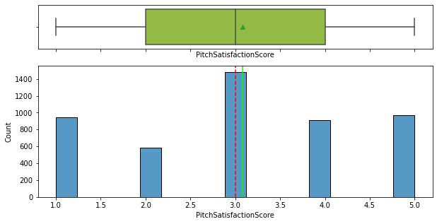

```python
boxplot_hitogram(df, "PitchSatisfactionScore", figsize=(10, 5), kde=False, bins=None)
```

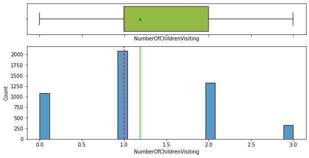

```python
boxplot_hitogram(df, "NumberOfChildrenVisiting", figsize=(10, 5), kde=False, bins=None)
```

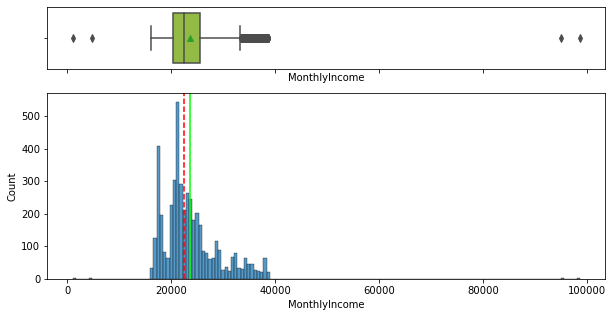

```python
boxplot_hitogram(df, "MonthlyIncome", figsize=(10, 5), kde=False, bins=None)
```

#### Observation

1) There are no outliers on the age variable. 2) There are outliers on the durationofpitch variable and skewed right. 3) There are outliers for the numberofpersonvisiting and the numberoffollowup variables. 4) The numberoftrips variable has outliers and skewed right. 5) Monthly income variable has outliers.

## Bivariate Analysis

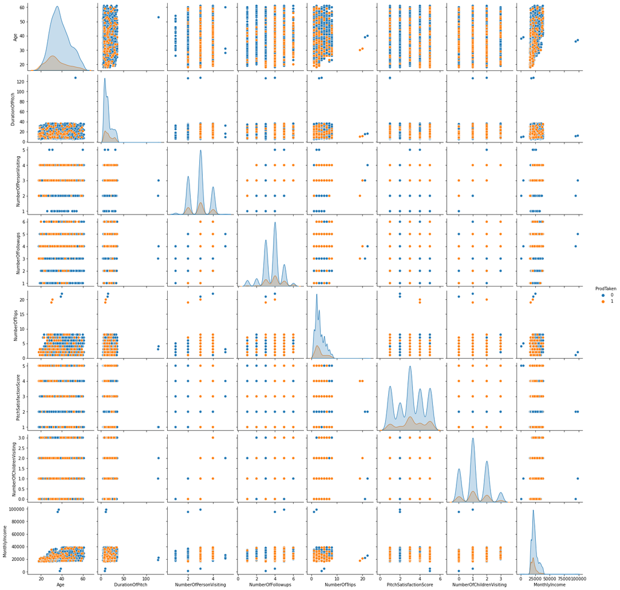

```python
sns.pairplot(df, hue="ProdTaken")
plt.show()
```

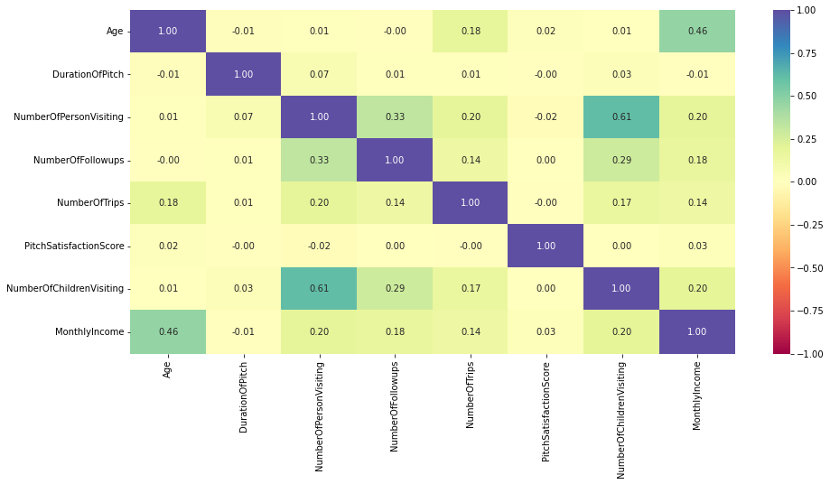

```python
plt.figure(figsize=(15, 7))
sns.heatmap(df.corr(), annot=True, vmin=-1, vmax=1, fmt=".2f", cmap="Spectral")
plt.show()
```

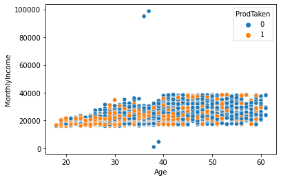

```python
sns.scatterplot(data=df, x="Age", y="MonthlyIncome", hue="ProdTaken")
```

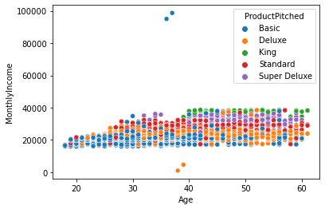

```python
sns.scatterplot(data=df, x="Age", y="MonthlyIncome", hue="ProductPitched")
```

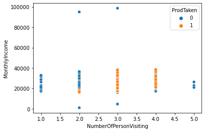

```python
sns.scatterplot(data=df, x="NumberOfPersonVisiting", y="MonthlyIncome", hue="ProdTaken")
```

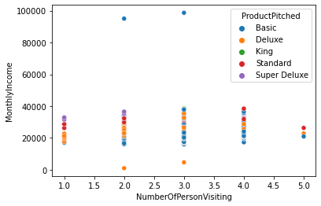

```python
sns.scatterplot(data=df, x="NumberOfPersonVisiting", y="MonthlyIncome", hue="ProductPitched")
```

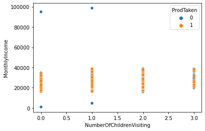

```python
sns.scatterplot(data=df, x="NumberOfChildrenVisiting", y="MonthlyIncome", hue="ProdTaken")
```

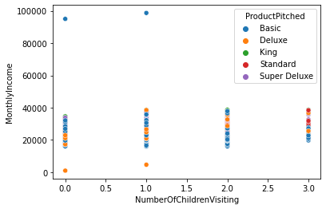

```python
sns.scatterplot(data=df, x="NumberOfChildrenVisiting", y="MonthlyIncome", hue="ProductPitched")
```

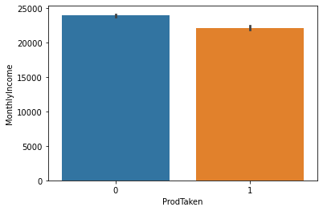

```python
sns.barplot(data=df, x="ProdTaken", y="MonthlyIncome")
```

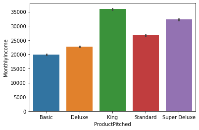

```python
sns.barplot(data=df, x="ProductPitched", y="MonthlyIncome")
```

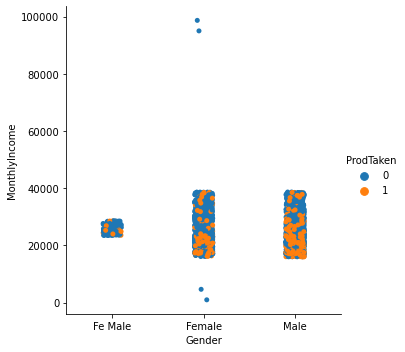

```python
sns.catplot(data=df, x="Gender", y="MonthlyIncome", hue="ProdTaken")
```

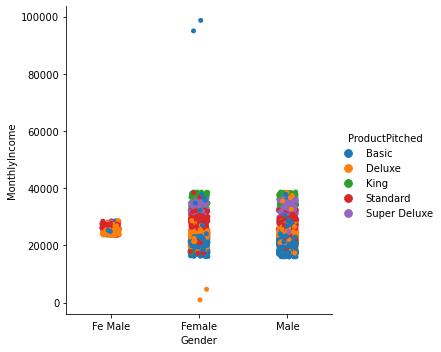

```python
plt.figure(figsize=(10,5))
sns.catplot(data=df, x="Gender", y="MonthlyIncome", hue="ProductPitched")
```